# Reproducible documentation of analyses

- Show All Code
- Hide All Code
- View Source

Does Computer-Based Feedback Enhance Revision Performance in Writing Non-Fictional Texts? A Meta-Analysis

Author

Affiliation

[blinded]

[blinded]

Published

November 29, 2024

**Display code**

We folded the code for better readability.  
You can display the code of our analyses

1. by clicking on “Code” > “Show All Code” in the top right corner or
2. by clicking in “Code” in each section of the document individually

```r
library(tidyverse)
library(here)
library(haven)
library(metafor)
library(kableExtra)
library(xfun)
library(rio)
library(broom)
```

# Import Data Sets

Two data sets were used:

- Data set “dataN35_prepost”: studies with pre-post design
- Data set “dataN15_control”: studies with pre-post-control design

Download the data (embeded in this HTML file):

- Download dataN35_prepost
- Download dataN15_control

```r
# Load data ----------------------------------------------------------------------
## Data set: studies with pre-post design
data_pp<-read_sav(here("02_data/05_major revision/dataN35_prepost.sav"))

## Data set: studies with pre-post-control design
data_c<-read_sav(here("02_data/05_major revision/dataN15_control.sav"))
```

```r
# Prepare data set
data_pp <- data_pp %>%
  mutate(id = 1:35)

data_c <- data_c %>%
  mutate(id = 1:15)
```

# Pre-Post comparison (without control)

## Meta-analytic effect

As we did not find the pre-post test correlation reported in any of the studies, we ran a sensitivity analysis.

One of the studies with control group design provided open data (Burkhart et al., 2020) so that we were able to calculate its pre-post-test correlations (r = .72), which we used as an anchor for the sensitivity analysis.

We included a broad range of 26 (conservative) plausible values in the sensitivity analyses with correlations from r= .50 - .75, using steps of .01.

**This will produce results from 26 meta-analyses.** By the variation of results, we are able to estimate the robustness of our analyses.

```r
# Establish empty data frame to be filled with results
sensitivity <- data.frame(ri_t = as.numeric(),   # assumed pre-post correlation
                          beta = as.numeric(),   # meta-analytic ES
                          pvalue = as.numeric(), # p value of ES
                          se = as.numeric(),     # SE of meta-analytic ES
                          sigma2 = as.numeric(),   # Tau squared
                          yi.f01 = as.numeric(), # ES of individual studies
                          yi.f02 = as.numeric(),
                          yi.f03 = as.numeric(),
                          yi.f04 = as.numeric(),
                          yi.f05 = as.numeric(),
                          yi.f06 = as.numeric(),
                          yi.f07 = as.numeric(),
                          yi.f08 = as.numeric(),
                          yi.f09 = as.numeric(),
                          yi.f10 = as.numeric(),
                          yi.f11 = as.numeric(),
                          yi.f12 = as.numeric(),
                          yi.f13 = as.numeric(),
                          yi.f14 = as.numeric(),
                          yi.f15 = as.numeric(),
                          yi.f16 = as.numeric(),
                          yi.f17 = as.numeric(),
                          yi.f18 = as.numeric(),
                          yi.f19 = as.numeric(),
                          yi.f20 = as.numeric(),
                          yi.f21 = as.numeric(),
                          yi.f22 = as.numeric(),
                          yi.f23 = as.numeric(),
                          yi.f24 = as.numeric(),
                          yi.f25 = as.numeric(),
                          yi.f26 = as.numeric(),
                          yi.f27 = as.numeric(),
                          yi.f28 = as.numeric(),
                          yi.f29 = as.numeric(),
                          yi.f30 = as.numeric(),
                          yi.f31 = as.numeric(),
                          yi.f32 = as.numeric(),
                          yi.f33 = as.numeric(),
                          yi.f34 = as.numeric(),
                          yi.f35 = as.numeric(),
                          sei.f01 = as.numeric(),  # SEs of ES of individual studies
                          sei.f02 = as.numeric(),
                          sei.f03 = as.numeric(),
                          sei.f04 = as.numeric(),
                          sei.f05 = as.numeric(),
                          sei.f06 = as.numeric(),
                          sei.f07 = as.numeric(),
                          sei.f08 = as.numeric(),
                          sei.f09 = as.numeric(),
                          sei.f10 = as.numeric(),
                          sei.f11 = as.numeric(),
                          sei.f12 = as.numeric(),
                          sei.f13 = as.numeric(),
                          sei.f14 = as.numeric(),
                          sei.f15 = as.numeric(),
                          sei.f16 = as.numeric(),
                          sei.f17 = as.numeric(),
                          sei.f18 = as.numeric(),
                          sei.f19 = as.numeric(),
                          sei.f20 = as.numeric(),
                          sei.f21 = as.numeric(),
                          sei.f22 = as.numeric(),
                          sei.f23 = as.numeric(),
                          sei.f24 = as.numeric(),
                          sei.f25 = as.numeric(),
                          sei.f26 = as.numeric(),
                          sei.f27 = as.numeric(),
                          sei.f28 = as.numeric(),
                          sei.f29 = as.numeric(),
                          sei.f30 = as.numeric(),
                          sei.f31 = as.numeric(),
                          sei.f32 = as.numeric(),
                          sei.f33 = as.numeric(),
                          sei.f34 = as.numeric(),
                          sei.f35 = as.numeric()
)

# starting loop over 26 possible pre-post-correlations
for (ri_t in seq(from = .50, to=.75, by=.01)) {
  ###compute effect sizes for writing quality
  # effect sizes from within-subjects data
  data_pp_es <- escalc(measure = "SMCR",
                       m1i=M_post, m2i=M_pre,
                       sd1i=SD_post, sd2i=SD_pre,
                       ni=N, ri=rep(ri_t, 35), data = data_pp)
  # append the id variable
  data_pp_es$author <- data_pp$author
  data_pp_es$id <- data_pp$id

  # compute the meta-analysis
  rma_overall_clustered <- rma.mv(yi = yi,
                                  V = vi,
                                  data=data_pp_es,
                                  random = ~ 1 | author, # take clustered data into account
                                  method = "REML",
                                  digits = 3
                                  )

  # save estimates for sensitivity analysis
  sensitivity <- sensitivity %>%
    add_row(ri_t = ri_t,
            pvalue = rma_overall_clustered$pval,
            beta = rma_overall_clustered$beta[,1],
            se = rma_overall_clustered$se[1],
            sigma2 = rma_overall_clustered$sigma2[1],
            yi.f01 = rma_overall_clustered$yi.f[1],
            yi.f02 = rma_overall_clustered$yi.f[2],
            yi.f03 = rma_overall_clustered$yi.f[3],
            yi.f04 = rma_overall_clustered$yi.f[4],
            yi.f05 = rma_overall_clustered$yi.f[5],
            yi.f06 = rma_overall_clustered$yi.f[6],
            yi.f07 = rma_overall_clustered$yi.f[7],
            yi.f08 = rma_overall_clustered$yi.f[8],
            yi.f09 = rma_overall_clustered$yi.f[9],
            yi.f10 = rma_overall_clustered$yi.f[10],
            yi.f11 = rma_overall_clustered$yi.f[11],
            yi.f12 = rma_overall_clustered$yi.f[12],
            yi.f13 = rma_overall_clustered$yi.f[13],
            yi.f14 = rma_overall_clustered$yi.f[14],
            yi.f15 = rma_overall_clustered$yi.f[15],
            yi.f16 = rma_overall_clustered$yi.f[16],
            yi.f17 = rma_overall_clustered$yi.f[17],
            yi.f18 = rma_overall_clustered$yi.f[18],
            yi.f19 = rma_overall_clustered$yi.f[19],
            yi.f20 = rma_overall_clustered$yi.f[20],
            yi.f21 = rma_overall_clustered$yi.f[21],
            yi.f22 = rma_overall_clustered$yi.f[22],
            yi.f23 = rma_overall_clustered$yi.f[23],
            yi.f24 = rma_overall_clustered$yi.f[24],
            yi.f25 = rma_overall_clustered$yi.f[25],
            yi.f26 = rma_overall_clustered$yi.f[26],
            yi.f27 = rma_overall_clustered$yi.f[27],
            yi.f28 = rma_overall_clustered$yi.f[28],
            yi.f29 = rma_overall_clustered$yi.f[29],
            yi.f30 = rma_overall_clustered$yi.f[30],
            yi.f31 = rma_overall_clustered$yi.f[31],
            yi.f32 = rma_overall_clustered$yi.f[32],
            yi.f33 = rma_overall_clustered$yi.f[33],
            yi.f34 = rma_overall_clustered$yi.f[34],
            yi.f35 = rma_overall_clustered$yi.f[35],
            sei.f01 = sqrt(data_pp_es$vi[1]),
            sei.f02 = sqrt(data_pp_es$vi[2]),
            sei.f03 = sqrt(data_pp_es$vi[3]),
            sei.f04 = sqrt(data_pp_es$vi[4]),
            sei.f05 = sqrt(data_pp_es$vi[5]),
            sei.f06 = sqrt(data_pp_es$vi[6]),
            sei.f07 = sqrt(data_pp_es$vi[7]),
            sei.f08 = sqrt(data_pp_es$vi[8]),
            sei.f09 = sqrt(data_pp_es$vi[9]),
            sei.f10 = sqrt(data_pp_es$vi[10]),
            sei.f11 = sqrt(data_pp_es$vi[11]),
            sei.f12 = sqrt(data_pp_es$vi[12]),
            sei.f13 = sqrt(data_pp_es$vi[13]),
            sei.f14 = sqrt(data_pp_es$vi[14]),
            sei.f15 = sqrt(data_pp_es$vi[15]),
            sei.f16 = sqrt(data_pp_es$vi[16]),
            sei.f17 = sqrt(data_pp_es$vi[17]),
            sei.f18 = sqrt(data_pp_es$vi[18]),
            sei.f19 = sqrt(data_pp_es$vi[19]),
            sei.f20 = sqrt(data_pp_es$vi[20]),
            sei.f21 = sqrt(data_pp_es$vi[21]),
            sei.f22 = sqrt(data_pp_es$vi[22]),
            sei.f23 = sqrt(data_pp_es$vi[23]),
            sei.f24 = sqrt(data_pp_es$vi[24]),
            sei.f25 = sqrt(data_pp_es$vi[25]),
            sei.f26 = sqrt(data_pp_es$vi[26]),
            sei.f27 = sqrt(data_pp_es$vi[27]),
            sei.f28 = sqrt(data_pp_es$vi[28]),
            sei.f29 = sqrt(data_pp_es$vi[29]),
            sei.f30 = sqrt(data_pp_es$vi[30]),
            sei.f31 = sqrt(data_pp_es$vi[31]),
            sei.f32 = sqrt(data_pp_es$vi[32]),
            sei.f33 = sqrt(data_pp_es$vi[33]),
            sei.f34 = sqrt(data_pp_es$vi[34]),
            sei.f35 = sqrt(data_pp_es$vi[35])
    )
}
```

### Overview of meta-analytic ES

**Results from all 26 meta-analyses:**

- ri_t: assumed pre-post-correlation
- beta: meta-analytic ES
- se: SE of meta-analytic ES
- pvalue: p value of meta-analytic ES

```r
sensitivity %>%
  dplyr::select(ri_t, beta, se, pvalue, sigma2) %>%
  kbl() %>%
  kable_styling(bootstrap_options = c("striped", "hover"))
```

| ri_t | beta | se | pvalue | sigma2 |
| --- | --- | --- | --- | --- |
| 0.50 | 0.3247592 | 0.0811967 | 6.34e-05 | 0.1128835 |
| 0.51 | 0.3249218 | 0.0811442 | 6.22e-05 | 0.1129956 |
| 0.52 | 0.3250845 | 0.0810913 | 6.10e-05 | 0.1131078 |
| 0.53 | 0.3252474 | 0.0810381 | 5.98e-05 | 0.1132201 |
| 0.54 | 0.3254104 | 0.0809845 | 5.86e-05 | 0.1133325 |
| 0.55 | 0.3255735 | 0.0809304 | 5.75e-05 | 0.1134447 |
| 0.56 | 0.3257367 | 0.0808759 | 5.63e-05 | 0.1135569 |
| 0.57 | 0.3258999 | 0.0808209 | 5.52e-05 | 0.1136689 |
| 0.58 | 0.3260630 | 0.0807654 | 5.41e-05 | 0.1137807 |
| 0.59 | 0.3262261 | 0.0807093 | 5.30e-05 | 0.1138922 |
| 0.60 | 0.3263891 | 0.0806527 | 5.19e-05 | 0.1140032 |
| 0.61 | 0.3265520 | 0.0805955 | 5.08e-05 | 0.1141138 |
| 0.62 | 0.3267146 | 0.0805377 | 4.98e-05 | 0.1142238 |
| 0.63 | 0.3268770 | 0.0804792 | 4.87e-05 | 0.1143331 |
| 0.64 | 0.3270391 | 0.0804199 | 4.77e-05 | 0.1144416 |
| 0.65 | 0.3272007 | 0.0803599 | 4.67e-05 | 0.1145492 |
| 0.66 | 0.3273619 | 0.0802991 | 4.57e-05 | 0.1146557 |
| 0.67 | 0.3275226 | 0.0802373 | 4.47e-05 | 0.1147609 |
| 0.68 | 0.3276827 | 0.0801747 | 4.37e-05 | 0.1148648 |
| 0.69 | 0.3278420 | 0.0801110 | 4.27e-05 | 0.1149672 |
| 0.70 | 0.3280005 | 0.0800463 | 4.17e-05 | 0.1150677 |
| 0.71 | 0.3281582 | 0.0799805 | 4.08e-05 | 0.1151663 |
| 0.72 | 0.3283148 | 0.0799134 | 3.98e-05 | 0.1152627 |
| 0.73 | 0.3284702 | 0.0798450 | 3.89e-05 | 0.1153567 |
| 0.74 | 0.3286244 | 0.0797751 | 3.80e-05 | 0.1154479 |
| 0.75 | 0.3287771 | 0.0797038 | 3.71e-05 | 0.1155360 |

**We summarize these results:**

- ES_mean: meta-analytic ES (mean over the 26 meta-analyses)
- ES_min: meta-analytic ES (min of the 26 meta-analyses)
- ES_max: meta-analytic ES (max of the 26 meta-analyses)
- CI_lower_mean: lower CI of meta-analytic ES (mean over the 26 meta-analyses)
- CI_lower_min: lower CI of meta-analytic ES (min of the 26 meta-analyses)
- CI_lower_max: lower CI of meta-analytic ES (max of the 26 meta-analyses)
- CI_upper_mean: upper CI of meta-analytic ES (mean over the 26 meta-analyses)
- CI_upper_min: upper CI of meta-analytic ES (min of the 26 meta-analyses)
- CI_upper_max: upper CI of meta-analytic ES (max of the 26 meta-analyses)
- pvalue_mean: p value of meta-analytic ES (mean over the 26 meta-analyses)
- pvalue_min: p value of meta-analytic ES (min of the 26 meta-analyses)
- pvalue_max: p value of meta-analytic ES (max of the 26 meta-analyses)

```r
# compute mean, min and max of ES, CI and pvalue from meta-analysis
sensitivity %>%
  dplyr::summarise(ES_mean = mean(beta),
                   ES_min  = min(beta),
                   ES_max  = max(beta),
                   CI_lower_mean = mean(beta-(1.96*se)),
                   CI_lower_min = min(beta-(1.96*se)),
                   CI_lower_max = max(beta-(1.96*se)),
                   CI_upper_mean = mean(beta+(1.96*se)),
                   CI_upper_min = min(beta+(1.96*se)),
                   CI_upper_max = max(beta+(1.96*se)),
                   pvalue_mean = mean(pvalue),
                   pvalue_min = min(pvalue),
                   pvalue_max = max(pvalue),
                   sigma2_mean = mean(sigma2)) %>%
  kbl() %>%
  kable_styling(bootstrap_options = c("striped", "hover")) %>%
  column_spec(1, background = "#C74A48") %>%
  column_spec(2, background = "#B54341") %>%
  column_spec(3, background = "#913634") %>%
  column_spec(4, background = "#27A357") %>%
  column_spec(5, background = "#208748") %>%
  column_spec(6, background = "#186636") %>%
  column_spec(7, background = "#B244B8") %>%
  column_spec(8, background = "#8A358F") %>%
  column_spec(9, background = "#6A296E") %>%
  column_spec(10, background = "#9E8A47") %>%
  column_spec(11, background = "#8F7C40") %>%
  column_spec(12, background = "#6E6031")
```

| ES_mean | ES_min | ES_max | CI_lower_mean | CI_lower_min | CI_lower_max | CI_upper_mean | CI_upper_min | CI_upper_max | pvalue_mean | pvalue_min | pvalue_max | sigma2_mean |
| --- | --- | --- | --- | --- | --- | --- | --- | --- | --- | --- | --- | --- |
| 0.3267865 | 0.3247592 | 0.3287771 | 0.1690301 | 0.1656137 | 0.1725577 | 0.484543 | 0.4839047 | 0.4849966 | 4.96e-05 | 3.71e-05 | 6.34e-05 | 0.1142551 |

**We summarize the same aspects for all 35 studies:**

```r
# compute mean, min and max of ES and CI from each study
sensitivity %>%
  dplyr::select(-c(beta, pvalue, se, sigma2)) %>%
  pivot_longer(c(2:71),                       # reshape data from
               names_to = "variable",         # sensitivity analysis
               values_to = "values") %>%
  mutate(id = as.numeric(str_sub(variable, -2, -1)),
         variable = str_sub(variable, 1, -5)) %>%
  pivot_wider(id_cols = c(id, ri_t),
              names_from = "variable",
              values_from = "values") %>%
  group_by(id) %>%
  dplyr::summarise(ES = mean(yi),
                   CI_lower_mean = mean(yi-(1.96*sei)),
                   CI_lower_min  = min(yi-(1.96*sei)),
                   CI_lower_max  = max(yi-(1.96*sei)),
                   CI_upper_mean = mean(yi+(1.96*sei)),
                   CI_upper_min  = min(yi+(1.96*sei)),
                   CI_upper_max  = max(yi+(1.96*sei)))  %>%
  right_join(data_pp[c("id", "author")],., by = "id") %>%
  dplyr::select(-id) %>%
  kbl() %>%
  kable_styling(bootstrap_options = c("striped", "hover")) %>%
  column_spec(2, background = "#C74A48") %>%
  column_spec(3, background = "#27A357") %>%
  column_spec(4, background = "#208748") %>%
  column_spec(5, background = "#186636") %>%
  column_spec(6, background = "#B244B8") %>%
  column_spec(7, background = "#8A358F") %>%
  column_spec(8, background = "#6A296E")
```

| author | ES | CI_lower_mean | CI_lower_min | CI_lower_max | CI_upper_mean | CI_upper_min | CI_upper_max |
| --- | --- | --- | --- | --- | --- | --- | --- |
| Burkhart et al., 2020 | 0.5523298 | 0.1884357 | 0.1396660 | 0.2418230 | 0.9162239 | 0.8628365 | 0.9649935 |
| Burkhart et al., 2020 | 0.9468460 | 0.5185913 | 0.4750990 | 0.5651220 | 1.3751008 | 1.3285700 | 1.4185930 |
| Burkhart et al., 2020 | 0.5474205 | 0.1611087 | 0.1091827 | 0.2179674 | 0.9337323 | 0.8768736 | 0.9856583 |
| Butterfuss et al., 2022 | 0.3693420 | 0.1221478 | 0.0856816 | 0.1624593 | 0.6165361 | 0.5762247 | 0.6530023 |
| Correnti et al., 2022 | 0.4886117 | 0.3769843 | 0.3614658 | 0.3940336 | 0.6002390 | 0.5831898 | 0.6157575 |
| Frost, 2008 | -0.7444141 | -1.2559052 | -1.3163124 | -1.1905244 | -0.2329230 | -0.2983038 | -0.1725157 |
| Frost, 2008 | 0.5098447 | 0.1278835 | 0.0754088 | 0.1854660 | 0.8918060 | 0.8342235 | 0.9442807 |
| Jiang et al. 2023 | 0.3854782 | 0.3128946 | 0.3022644 | 0.3246365 | 0.4580618 | 0.4463198 | 0.4686919 |
| Kellogg et al., 2010 | 0.5599477 | 0.1440581 | 0.0885747 | 0.2047681 | 0.9758374 | 0.9151273 | 1.0313207 |
| Kellogg et al., 2010 | 0.6160619 | 0.1925698 | 0.1380135 | 0.2520697 | 1.0395539 | 0.9800540 | 1.0941103 |
| Lachner & Neuburg, 2019 | 0.8266904 | 0.4597535 | 0.4189307 | 0.5037250 | 1.1936273 | 1.1496559 | 1.2344501 |
| Lachner et al., 2017a | 0.1397961 | -0.0526816 | -0.0832118 | -0.0186554 | 0.3322738 | 0.2982477 | 0.3628041 |
| Lachner et al., 2017a | 0.0924087 | -0.1005976 | -0.1314303 | -0.0662055 | 0.2854151 | 0.2510230 | 0.3162478 |
| Lachner et al., 2017a | 0.0679507 | -0.1046745 | -0.1323217 | -0.0738263 | 0.2405760 | 0.2097278 | 0.2682232 |
| Lachner et al., 2017a | 0.1811383 | -0.0121950 | -0.0426010 | 0.0216590 | 0.3744716 | 0.3406176 | 0.4048776 |
| Lachner et al., 2017a | 0.1271899 | -0.0461110 | -0.0736592 | -0.0154005 | 0.3004907 | 0.2697802 | 0.3280389 |
| Lachner et al., 2017a | 0.1253283 | -0.0681455 | -0.0989098 | -0.0338486 | 0.3188021 | 0.2845052 | 0.3495664 |
| Lachner et al., 2017b (Study 2) | 0.9619445 | 0.4918569 | 0.4446720 | 0.5422968 | 1.4320322 | 1.3815922 | 1.4792170 |
| Lachner et al., 2017b (Study 3) | 0.6047624 | 0.0814419 | 0.0135376 | 0.1555487 | 1.1280829 | 1.0539761 | 1.1959873 |
| McCarthy et al., 2019 | 0.2313808 | 0.0094321 | -0.0250184 | 0.0477311 | 0.4533296 | 0.4150306 | 0.4877801 |
| McCarthy et al., 2019 | 0.1974007 | -0.0253482 | -0.0602434 | 0.0134862 | 0.4201497 | 0.3813152 | 0.4550448 |
| McCarthy et al., 2022 | 0.1999443 | -0.0210146 | -0.0556070 | 0.0174802 | 0.4209032 | 0.3824084 | 0.4554956 |
| McCarthy et al., 2022 | 0.1606750 | -0.0611010 | -0.0961369 | -0.0220718 | 0.3824511 | 0.3434219 | 0.4174869 |
| Niloy et al., 2023 | -0.6453676 | -0.7557967 | -0.7697542 | -0.7406008 | -0.5349384 | -0.5501343 | -0.5209809 |
| Palermo, 2017 | 0.4245133 | 0.3160277 | 0.3004321 | 0.3332205 | 0.5329989 | 0.5158061 | 0.5485945 |
| Palermo, 2017 | 1.0165027 | 0.8865236 | 0.8740219 | 0.8998490 | 1.1464818 | 1.1331564 | 1.1589834 |
| Roscoe et al., 2013 | 0.1220433 | -0.1734120 | -0.2204170 | -0.1210061 | 0.4174986 | 0.3650928 | 0.4645037 |
| Wang et al., 2020 | 0.1470437 | 0.0047903 | -0.0177433 | 0.0299002 | 0.2892971 | 0.2641872 | 0.3118307 |
| Ware, 2014 | 0.0541053 | -0.3558780 | -0.4216123 | -0.2825235 | 0.4640887 | 0.3907342 | 0.5298229 |
| Wilson et al., 2022 | 0.0419532 | -0.0749281 | -0.0936824 | -0.0539978 | 0.1588346 | 0.1379043 | 0.1775889 |
| Wilson et al., 2022 | -0.0576379 | -0.1809399 | -0.2007043 | -0.1588849 | 0.0656641 | 0.0436091 | 0.0854285 |
| Wilson et al., 2022 | 0.2590675 | 0.1277775 | 0.1075718 | 0.1502187 | 0.3903575 | 0.3679164 | 0.4105633 |
| Wilson et al., 2023 | 0.6675031 | 0.3801957 | 0.3444127 | 0.4191023 | 0.9548104 | 0.9159038 | 0.9905934 |
| Wilson et al., 2023 | 0.6990417 | 0.4085314 | 0.3731168 | 0.4469652 | 0.9895521 | 0.9511183 | 1.0249666 |
| Zhu et al., 2017 | 0.3264432 | 0.1791629 | 0.1570410 | 0.2036654 | 0.4737236 | 0.4492211 | 0.4958454 |

### Forest Plot

In order to be able to display a forest plot, we calculated a meta-analysis with the mean assumed pre-post-correlation (r=.625).

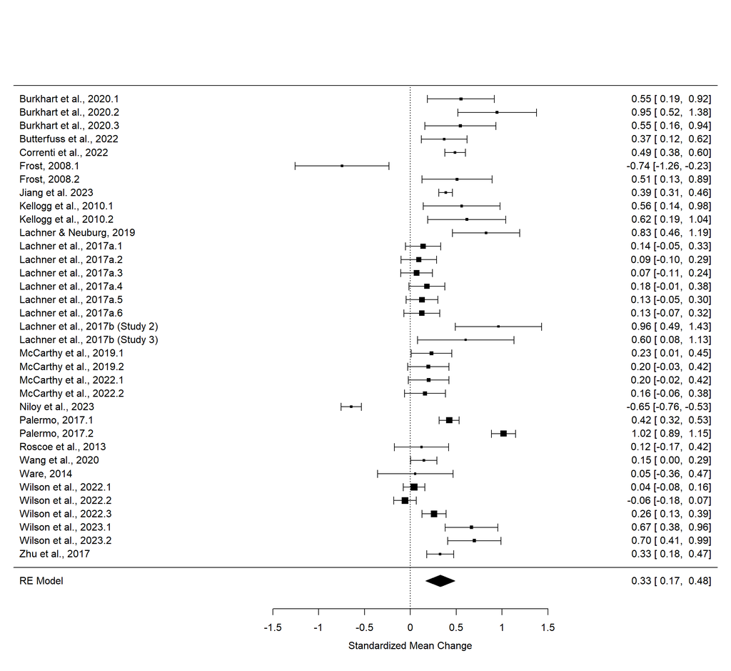

```r
## FOREST PLOT with mean correlation
###compute effect sizes for writing quality
# effect sizes from within-subjects data
data_pp_es <- escalc(measure = "SMCR",
                     m1i=data_pp$M_post, m2i=data_pp$M_pre,
                     sd1i=data_pp$SD_post, sd2i=data_pp$SD_pre,
                     ni=data_pp$N, ri=rep(.625, 35),
                     slab = data_pp$author)
# append the author and id variable
data_pp_es$author <- data_pp$author
data_pp_es$id <- data_pp$id

REM <- rma.mv(yi = yi,
              V = vi,
              data=data_pp_es,
              random = ~ 1 | author,
              method = "REML",
              digits = 3)

###FOREST PLOT
forest(REM)
```

### Fitting models

Model 1 without cluster vs. Model 2 clustered for author. Better fit for Model 2.

```r
model1 <- rma.mv(
  yi = yi,
  V = vi,
  data = data_pp_es,
  method = "REML")

model2 <- rma.mv(
  yi = yi,
  V = vi,
  data = data_pp_es,
  random = ~ 1 | author,
  method = "REML")

modelfit<-anova(model1, model2)
modelfit #better fit for model 2
```

```
        df      AIC      BIC     AICc    logLik      LRT   pval       QE
Full     2  66.3090  69.3617  66.6961  -31.1545                 552.2535
Reduced  1 470.5480 472.0744 470.6730 -234.2740 406.2390 <.0001 552.2535
```

```r
##Robust variance estimation
# RVE without cluster (dummy coded)
robust(REM, cluster = id)
```

```
Multivariate Meta-Analysis Model (k = 35; method: REML)

Variance Components:

           estim   sqrt  nlvls  fixed  factor
sigma^2    0.114  0.338     20     no  author

Test for Heterogeneity:
Q(df = 34) = 552.253, p-val < .001

Number of estimates:   35
Number of clusters:    35
Estimates per cluster: 1

Model Results:

estimate     se¹   tval¹  df¹   pval¹  ci.lb¹  ci.ub¹
   0.327  0.076   4.322   34   <.001   0.173   0.480   ***

---
Signif. codes:  0 '***' 0.001 '**' 0.01 '*' 0.05 '.' 0.1 ' ' 1

1) results based on cluster-robust inference (var-cov estimator: CR1,
   approx t-test and confidence interval, df: residual method)
```

```r
# RVE for author clustered:
robust(REM, cluster = author)
```

```
Multivariate Meta-Analysis Model (k = 35; method: REML)

Variance Components:

           estim   sqrt  nlvls  fixed  factor
sigma^2    0.114  0.338     20     no  author

Test for Heterogeneity:
Q(df = 34) = 552.253, p-val < .001

Number of estimates:   35
Number of clusters:    20
Estimates per cluster: 1-6 (mean: 1.75, median: 1)

Model Results:

estimate     se¹   tval¹  df¹   pval¹  ci.lb¹  ci.ub¹
   0.327  0.080   4.061   19   <.001   0.158   0.495   ***

---
Signif. codes:  0 '***' 0.001 '**' 0.01 '*' 0.05 '.' 0.1 ' ' 1

1) results based on cluster-robust inference (var-cov estimator: CR1,
   approx t-test and confidence interval, df: residual method)
```

## Bias estimation

### Funnel plot

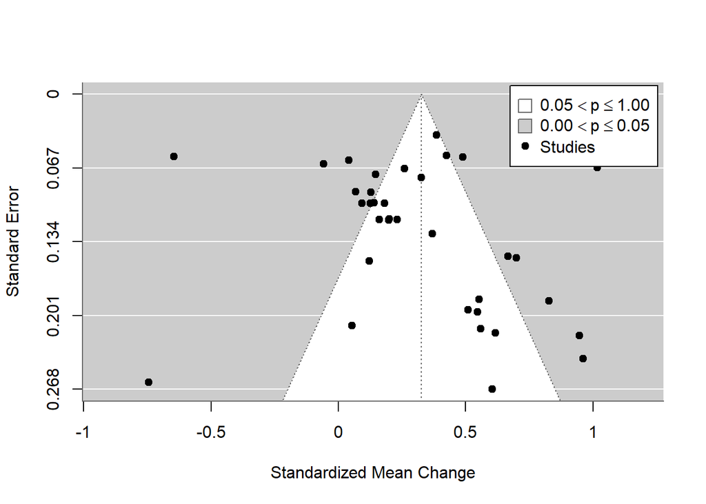

```r
funnel(REM, legend = T)
```

### Trim and fill

```r
##Trim & fill
rma_trimfill <- rma(yi, vi, data=data_pp_es) # compute random-effects model without
                                             # clustering, as trimfill() can't handle
                                             # these objects
taf_overall <- trimfill(rma_trimfill)
taf_overall
```

```
Estimated number of missing studies on the left side: 7 (SE = 3.9312)

Random-Effects Model (k = 42; tau^2 estimator: REML)

tau^2 (estimated amount of total heterogeneity): 0.1674 (SE = 0.0416)
tau (square root of estimated tau^2 value):      0.4092
I^2 (total heterogeneity / total variability):   94.90%
H^2 (total variability / sampling variability):  19.59

Test for Heterogeneity:
Q(df = 41) = 782.3426, p-val < .0001

Model Results:

estimate      se    zval    pval   ci.lb   ci.ub
  0.1917  0.0671  2.8564  0.0043  0.0602  0.3232  **

---
Signif. codes:  0 '***' 0.001 '**' 0.01 '*' 0.05 '.' 0.1 ' ' 1
```

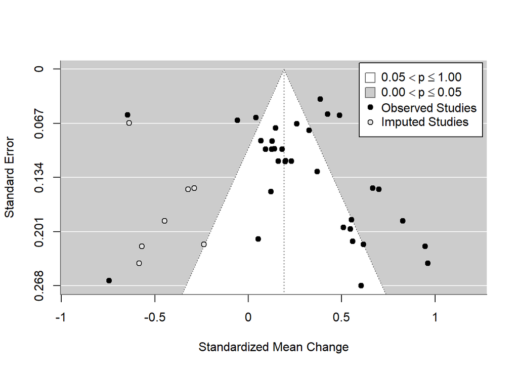

```r
funnel(taf_overall, legend = T)
```

### Egger’s test

```r
regtest(rma_trimfill)
```

```
Regression Test for Funnel Plot Asymmetry

Model:     mixed-effects meta-regression model
Predictor: standard error

Test for Funnel Plot Asymmetry: z = 1.8153, p = 0.0695
Limit Estimate (as sei -> 0):   b = 0.0949 (CI: -0.1600, 0.3498)
```

## Moderators

For reasons of clarity, we will report results from the moderation analyses based on the meta-analysis with the mean correlation of r = .625 as the ES does not vary due to different pre-post-correlation.

### Create functions for moderation analyses

```r
r_prepost <- 0.625

fn_meta_pre_post <- function(moderator, cor, data_pp_es) {
data_pp_es <- data_pp_es %>%
  mutate(r = cor)

data_pp_es <- escalc(
    measure = "SMCR",
    m1i = M_post,
    sd1i = SD_post,
    m2i = M_pre,
    sd2i = SD_pre,
    ni = N,
    ri = r,
    data = data_pp_es
  )

# V <- vcalc(vi = vi, cluster = author, subgroup = group, data = data_pp_es)

REM <- rma.mv(
    yi = yi,
    V = vi,
    data = data_pp_es,
    mods = as.formula(paste("~ factor(", moderator, ") - 1")),
    random = ~ 1 | author,
    method = "REML",
    digits = 2,
    test = "t",
    dfs = "contain")

  return(summary(REM))
}

# Q-tests
fn_meta_qtest<- function(moderator, cor, data_pp_es){
  REM <- fn_meta_pre_post(moderator, cor, data_pp_es)
  q_extract <- data.frame(
    qe_value = format(round(REM$QE, 3), nsmall = 2),
    qe_df = REM$QEdf,
    qe_p = format(round(REM$QEp, 3), nsmall = 3),
    f_value = format(round(REM$QM, 3), nsmall = 2),
    f_df1 = REM$QMdf[1],
    f_df2 = REM$QMdf[2],
    f_p = format(round(REM$QMp, 3), nsmall = 3))

  q_results <- q_extract %>%
    mutate(moderator = moderator) %>%
    mutate(qe_p = ifelse(qe_p < .001, "< .001", as.character(qe_p))) %>%
    mutate(qe_p = gsub("^0\\.", ".", qe_p)) %>%
    mutate(f_p = ifelse(f_p < .001, "< .001", as.character(f_p))) %>%
    mutate(f_p = gsub("^0\\.", ".", f_p)) %>%
    mutate(qm_statistics = paste0("QE = ", qe_value,
                                  ", df = ", qe_df,
                                  ", p = ", qe_p,
                                  "\nF(", f_df1,
                                  ", ", f_df2,
                                  ") = ", f_value,
                                  ", p = ", f_p),
           .keep = "unused")
}
```

### Moderator analyses

```r
# included moderators
moderators <- c("rep_numeric", "rep_graphical", "rep_highlighting",
  "rep_text_based", "rep_nr", "FB_order", "FB_specificity",
  "order_outcome", "rank_wq", "reliability_measurement", "treatment_fidelity",
  "writing_tests", "post_measure", "experiment",
  "validated_tool", "ceiling_or_flooring_effect",
  "FB_tool_numbers", "manuscript_type", "education_dummy",
  "setting", "country", "genre", "amount",
  "coding", "system_type", "teacher_effects"
)


# Run moderator analysis
results_moderation <- data.frame()

for (mod in moderators) {
  result <- fn_meta_pre_post(moderator = mod, cor = r_prepost, data_pp_es = data_pp) %>% broom::tidy() # JS
  result$moderator <- mod
  results_moderation <- bind_rows(results_moderation, result)
}


# Q-Test results
qtest_results_moderation <- data.frame()

# Loop through each moderator
for (mod in moderators) {
  qtest <- fn_meta_qtest(moderator = mod, cor = r_prepost, data_pp_es = data_pp)
  qtest_results_moderation <- rbind(qtest_results_moderation, data.frame(moderator = mod, q_test = qtest))}

# Customize dataset -------------------------------------------------------
number_of_effects <- data_pp %>%
  dplyr::select(any_of(moderators)) %>%
  pivot_longer(everything(), names_to = "moderator",
               values_to = "term", values_transform = as.character) %>%
  count(moderator, term, name = "k")

descriptive_data <- data_pp %>%
  dplyr::select(N, any_of(moderators)) %>%
  pivot_longer(-N, names_to = "moderator",
               values_to = "term", values_transform = as.character) %>%
  group_by(moderator, term) %>%
  summarize(N = sum(N)) %>%
  left_join(., number_of_effects, by = c("moderator", "term"))

prepost_final <- results_moderation %>%
  mutate(term = str_remove(term, "^[^)]*\\)")) %>%
  mutate(sig = case_when(
    p.value < .001 ~ "***",
    p.value < .01 ~ "**",
    p.value < .05 ~ "*",
    TRUE ~ "ns"
  )) %>%
  mutate(across(where(is.numeric), ~ round(.x, 3))) %>%
  mutate(across(where(is.numeric), ~ format(.x, nsmall = 3)))%>%
  mutate(p.value = ifelse(p.value < .001, "< .001", as.character(p.value))) %>%
  mutate(p.value = gsub("^0\\.", ".", p.value)) %>%
  left_join(., descriptive_data, by = c("moderator", "term")) %>%
  select(moderator, term, sig, k, N, estimate, std.error, statistic, p.value) %>%
  mutate(moderator = if_else(duplicated(moderator), NA_character_, moderator)) %>%
  left_join(., qtest_results_moderation, by = "moderator") %>%
  select(-q_test.moderator)


# Post-hoc tests -------------------------------------------------
generate_contrast_matrix <- function(p) {
  if (p < 2) stop("p must be at least 2.")

  # Initialize an empty list to store rows
  contrast_list <- list()

  # Loop through all pairs of coefficients (i, j)
  for (i in 1:(p-1)) {
    for (j in (i+1):p) {
      contrast <- rep(0, p)  # Initialize a row of zeros
      contrast[i] <- -1      # Contrast for the i-th coefficient
      contrast[j] <- 1       # Contrast for the j-th coefficient
      contrast_list <- append(contrast_list, list(contrast))
    }
  }

  contrast_matrix <- do.call(rbind, contrast_list)
  return(contrast_matrix)
}


results_posthoc <- data.frame()

for (mod in moderators) {
  result <- fn_meta_pre_post(moderator = mod, cor = r_prepost, data_pp_es = data_pp)
  result_posthoc <- result %>% broom::tidy()
  result_posthoc$moderator <- mod
  contrast_matrix <- generate_contrast_matrix(result$p)
  anova_result <- data.frame(anova(result, X = contrast_matrix))
  results_posthoc <- bind_rows(results_posthoc, anova_result)
}
```

# Pre-Post-Control comparison

## Meta-analytic effect

In this section, we used the same approach via sensitivity analyses as above.

```r
sensitivity <- data.frame(ri_t = as.numeric(),  # assumed pre-post correlation treatment group
                          ri_c = as.numeric(),  # assumed pre-post correlation control group
                          pvalue = as.numeric(), # p value of ES
                          beta = as.numeric(),   # meta-analytic ES
                          se = as.numeric(),     # SE of meta-analytic ES
                          sigma2 = as.numeric(),   # tau squared
                          yi.f01 = as.numeric(), # ES of individual studies
                          yi.f02 = as.numeric(),
                          yi.f03 = as.numeric(),
                          yi.f04 = as.numeric(),
                          yi.f05 = as.numeric(),
                          yi.f06 = as.numeric(),
                          yi.f07 = as.numeric(),
                          yi.f08 = as.numeric(),
                          yi.f09 = as.numeric(),
                          yi.f10 = as.numeric(),
                          yi.f11 = as.numeric(),
                          yi.f12 = as.numeric(),
                          yi.f13 = as.numeric(),
                          yi.f14 = as.numeric(),
                          yi.f15 = as.numeric(),
                          sei.f01 = as.numeric(),  # SEs of ES of individual studies
                          sei.f02 = as.numeric(),
                          sei.f03 = as.numeric(),
                          sei.f04 = as.numeric(),
                          sei.f05 = as.numeric(),
                          sei.f06 = as.numeric(),
                          sei.f07 = as.numeric(),
                          sei.f08 = as.numeric(),
                          sei.f09 = as.numeric(),
                          sei.f10 = as.numeric(),
                          sei.f11 = as.numeric(),
                          sei.f12 = as.numeric(),
                          sei.f13 = as.numeric(),
                          sei.f14 = as.numeric(),
                          sei.f15 = as.numeric()
                          )

for (ri_t in seq(from = .50, to=.75, by=.01)) {
  ###compute effect sizes for writing quality
  # effect sizes from between-subjects data
    dat_es_exp <- escalc(measure = "SMCR",
                     m1i = M_Feedback2,
                     m2i = M_Feedback,
                     sd1i = SD_Feedback2,
                     sd2i = SD_Feedback,
                     ni= N_Feedback,
                     ri=rep(ri_t, 15),
                     slab = author,
                     data = data_c)

    dat_es_con <- escalc(measure = "SMCR",
                     m1i = M_NoFeedback2,
                     m2i = M_NoFeedback,
                     sd1i = SD_NoFeedback2,
                     sd2i = SD_NoFeedback,
                     ni = N_noFeedback,
                     ri= rep((ri_t+.14), 15),
                     slab = author,
                     data = data_c)


  dat <- data_c %>%
  mutate(yi = dat_es_exp$yi - dat_es_con$yi,
         vi = dat_es_exp$vi + dat_es_con$vi)

  rma_overall_clustered <- rma.mv(
  yi = yi,
  V = vi,
  data = dat,
  random = ~ 1 | author,
  method = "REML",
  digits = 3
)

  sensitivity <- sensitivity %>%
    add_row(ri_t = ri_t,
            ri_c = (ri_t+.14),
            pvalue = rma_overall_clustered$pval,
            beta = rma_overall_clustered$beta[,1],
            se = rma_overall_clustered$se[1],
            sigma2 = rma_overall_clustered$sigma2[1],
            yi.f01 = rma_overall_clustered$yi.f[1],
            yi.f02 = rma_overall_clustered$yi.f[2],
            yi.f03 = rma_overall_clustered$yi.f[3],
            yi.f04 = rma_overall_clustered$yi.f[4],
            yi.f05 = rma_overall_clustered$yi.f[5],
            yi.f06 = rma_overall_clustered$yi.f[6],
            yi.f07 = rma_overall_clustered$yi.f[7],
            yi.f08 = rma_overall_clustered$yi.f[8],
            yi.f09 = rma_overall_clustered$yi.f[9],
            yi.f10 = rma_overall_clustered$yi.f[10],
            yi.f11 = rma_overall_clustered$yi.f[11],
            yi.f12 = rma_overall_clustered$yi.f[12],
            yi.f13 = rma_overall_clustered$yi.f[13],
            yi.f14 = rma_overall_clustered$yi.f[14],
            yi.f15 = rma_overall_clustered$yi.f[15],
            sei.f01 = sqrt(dat$vi[1]),
            sei.f02 = sqrt(dat$vi[2]),
            sei.f03 = sqrt(dat$vi[3]),
            sei.f04 = sqrt(dat$vi[4]),
            sei.f05 = sqrt(dat$vi[5]),
            sei.f06 = sqrt(dat$vi[6]),
            sei.f07 = sqrt(dat$vi[7]),
            sei.f08 = sqrt(dat$vi[8]),
            sei.f09 = sqrt(dat$vi[9]),
            sei.f10 = sqrt(dat$vi[10]),
            sei.f11 = sqrt(dat$vi[11]),
            sei.f12 = sqrt(dat$vi[12]),
            sei.f13 = sqrt(dat$vi[13]),
            sei.f14 = sqrt(dat$vi[14]),
            sei.f15 = sqrt(dat$vi[15])
    )
}
```

### Overview of meta-analytic ES

**Results from all 26 meta-analyses:**

- ri_t: assumed pre-post-correlation (treatment group)
- ri_c: assumed pre-post-correlation (control group)
- beta: meta-analytic ES
- se: SE of meta-analytic ES
- pvalue: p value of meta-analytic ES

```r
sensitivity %>%
  dplyr::select(ri_t, ri_c, beta, se, pvalue, sigma2) %>%
  kbl() %>%
  kable_styling(bootstrap_options = c("striped", "hover"))
```

| ri_t | ri_c | beta | se | pvalue | sigma2 |
| --- | --- | --- | --- | --- | --- |
| 0.50 | 0.64 | 0.0530020 | 0.2169730 | 0.8070146 | 0.3875505 |
| 0.51 | 0.65 | 0.0522063 | 0.2162200 | 0.8092066 | 0.3855326 |
| 0.52 | 0.66 | 0.0513865 | 0.2154551 | 0.8114916 | 0.3834785 |
| 0.53 | 0.67 | 0.0505417 | 0.2146779 | 0.8138747 | 0.3813879 |
| 0.54 | 0.68 | 0.0496707 | 0.2138883 | 0.8163617 | 0.3792603 |
| 0.55 | 0.69 | 0.0487722 | 0.2130861 | 0.8189583 | 0.3770955 |
| 0.56 | 0.70 | 0.0478450 | 0.2122711 | 0.8216715 | 0.3748936 |
| 0.57 | 0.71 | 0.0468877 | 0.2114427 | 0.8245074 | 0.3726532 |
| 0.58 | 0.72 | 0.0458989 | 0.2106010 | 0.8274740 | 0.3703746 |
| 0.59 | 0.73 | 0.0448769 | 0.2097456 | 0.8305792 | 0.3680576 |
| 0.60 | 0.74 | 0.0438201 | 0.2088764 | 0.8338318 | 0.3657022 |
| 0.61 | 0.75 | 0.0427266 | 0.2079931 | 0.8372414 | 0.3633081 |
| 0.62 | 0.76 | 0.0415945 | 0.2070955 | 0.8408181 | 0.3608755 |
| 0.63 | 0.77 | 0.0404217 | 0.2061834 | 0.8445733 | 0.3584045 |
| 0.64 | 0.78 | 0.0392058 | 0.2052567 | 0.8485190 | 0.3558952 |
| 0.65 | 0.79 | 0.0379443 | 0.2043151 | 0.8526685 | 0.3533480 |
| 0.66 | 0.80 | 0.0366347 | 0.2033587 | 0.8570363 | 0.3507634 |
| 0.67 | 0.81 | 0.0352739 | 0.2023872 | 0.8616382 | 0.3481419 |
| 0.68 | 0.82 | 0.0338588 | 0.2014006 | 0.8664915 | 0.3454842 |
| 0.69 | 0.83 | 0.0323858 | 0.2003988 | 0.8716154 | 0.3427915 |
| 0.70 | 0.84 | 0.0308513 | 0.1993820 | 0.8770306 | 0.3400647 |
| 0.71 | 0.85 | 0.0292509 | 0.1983501 | 0.8827602 | 0.3373053 |
| 0.72 | 0.86 | 0.0275801 | 0.1973033 | 0.8888297 | 0.3345149 |
| 0.73 | 0.87 | 0.0258338 | 0.1962418 | 0.8952670 | 0.3316954 |
| 0.74 | 0.88 | 0.0240063 | 0.1951659 | 0.9021033 | 0.3288492 |
| 0.75 | 0.89 | 0.0220915 | 0.1940759 | 0.9093731 | 0.3259786 |

**We summarize these results:**

- ES_mean: meta-analytic ES (mean over the 26 meta-analyses)
- ES_min: meta-analytic ES (min of the 26 meta-analyses)
- ES_max: meta-analytic ES (max of the 26 meta-analyses)
- CI_lower_mean: lower CI of meta-analytic ES (mean over the 26 meta-analyses)
- CI_lower_min: lower CI of meta-analytic ES (min of the 26 meta-analyses)
- CI_lower_max: lower CI of meta-analytic ES (max of the 26 meta-analyses)
- CI_upper_mean: upper CI of meta-analytic ES (mean over the 26 meta-analyses)
- CI_upper_min: upper CI of meta-analytic ES (min of the 26 meta-analyses)
- CI_upper_max: upper CI of meta-analytic ES (max of the 26 meta-analyses)
- pvalue_mean: p value of meta-analytic ES (mean over the 26 meta-analyses)
- pvalue_min: p value of meta-analytic ES (min of the 26 meta-analyses)
- pvalue_max: p value of meta-analytic ES (max of the 26 meta-analyses)

```r
# compute mean, min and max of ES, CI and pvalue from meta-analysis
sensitivity %>%
  dplyr::summarise(ES_mean = mean(beta),
                   ES_min  = min(beta),
                   ES_max  = max(beta),
                   CI_lower_mean        = mean(beta-(1.96*se)),
                   CI_lower_min = min(beta-(1.96*se)),
                   CI_lower_max = max(beta-(1.96*se)),
                   CI_upper_mean        = mean(beta+(1.96*se)),
                   CI_upper_min = min(beta+(1.96*se)),
                   CI_upper_max = max(beta+(1.96*se)),
                   pvalue_mean        = mean(pvalue),
                   pvalue_min = min(pvalue),
                   pvalue_max = max(pvalue),
                   sigma2_mean = mean(sigma2)) %>%
  kbl() %>%
  kable_styling(bootstrap_options = c("striped", "hover")) %>%
  column_spec(1, background = "#C74A48") %>%
  column_spec(2, background = "#B54341") %>%
  column_spec(3, background = "#913634") %>%
  column_spec(4, background = "#27A357") %>%
  column_spec(5, background = "#208748") %>%
  column_spec(6, background = "#186636") %>%
  column_spec(7, background = "#B244B8") %>%
  column_spec(8, background = "#8A358F") %>%
  column_spec(9, background = "#6A296E") %>%
  column_spec(10, background = "#9E8A47") %>%
  column_spec(11, background = "#8F7C40") %>%
  column_spec(12, background = "#6E6031")
```

| ES_mean | ES_min | ES_max | CI_lower_mean | CI_lower_min | CI_lower_max | CI_upper_mean | CI_upper_min | CI_upper_max | pvalue_mean | pvalue_min | pvalue_max | sigma2_mean |
| --- | --- | --- | --- | --- | --- | --- | --- | --- | --- | --- | --- | --- |
| 0.0397911 | 0.0220915 | 0.053002 | -0.3644322 | -0.3722651 | -0.3582973 | 0.4440143 | 0.4024803 | 0.4782691 | 0.848113 | 0.8070146 | 0.9093731 | 0.3585926 |

**We summarize the same aspects for all 15 studies:**

```r
data_c <- data_c %>%
  mutate(id = 1:15)

# compute mean, min and max of ES and CI from each study
sensitivity %>%
  dplyr::select(-c(beta, pvalue, se, sigma2)) %>%
  pivot_longer(c(3:32),                       # reshape data data from
               names_to = "variable",         # sensitivity analysis
               values_to = "values") %>%
  mutate(id = as.numeric(str_sub(variable, -2, -1)),
         variable = str_sub(variable, 1, -5)) %>%
  pivot_wider(id_cols = c(id, ri_t, ri_c),
              names_from = "variable",
              values_from = "values") %>%
  group_by(id) %>%
  dplyr::summarise(ES = mean(yi),    # compute mean, min and max
                   CI_lower_mean = mean(yi-(1.96*sei)),
                   CI_lower_min  = min(yi-(1.96*sei)),
                   CI_lower_max  = max(yi-(1.96*sei)),
                   CI_upper_mean = mean(yi+(1.96*sei)),
                   CI_upper_min  = min(yi+(1.96*sei)),
                   CI_upper_max  = max(yi+(1.96*sei)))  %>%
  right_join(data_c[c("id", "author")],., by = "id") %>%
  dplyr::select(-id) %>%
  kbl() %>%
  kable_styling(bootstrap_options = c("striped", "hover")) %>%
  column_spec(2, background = "#C74A48") %>%
  column_spec(3, background = "#27A357") %>%
  column_spec(4, background = "#208748") %>%
  column_spec(5, background = "#186636") %>%
  column_spec(6, background = "#B244B8") %>%
  column_spec(7, background = "#8A358F") %>%
  column_spec(8, background = "#6A296E")
```

| author | ES | CI_lower_mean | CI_lower_min | CI_lower_max | CI_upper_mean | CI_upper_min | CI_upper_max |
| --- | --- | --- | --- | --- | --- | --- | --- |
| Burkhart et al., 2020 | -0.0551590 | -0.5325316 | -0.6064646 | -0.4503603 | 0.4222135 | 0.3400422 | 0.4961465 |
| Burkhart et al., 2020 | 0.3393572 | -0.1888410 | -0.2574608 | -0.1139449 | 0.8675554 | 0.7926593 | 0.9361752 |
| Burkhart et al., 2020 | -0.0600683 | -0.5547445 | -0.6307687 | -0.4703230 | 0.4346078 | 0.3501864 | 0.5106320 |
| Frost, 2008 | -0.2127412 | -0.8246045 | -0.9416463 | -0.6908950 | 0.3991221 | 0.2654126 | 0.5161638 |
| Frost, 2008 | 3.6090403 | 2.4771441 | 2.4210059 | 2.5351247 | 4.7409365 | 4.6829559 | 4.7970748 |
| Kellogg et al., 2010 | -1.8694481 | -3.5416216 | -3.5709310 | -3.5119795 | -0.1972747 | -0.2269167 | -0.1679652 |
| Kellogg et al., 2010 | -1.6374698 | -3.3444032 | -3.3731221 | -3.3153716 | 0.0694636 | 0.0404320 | 0.0981826 |
| Lachner & Neuburg, 2019 | 0.1974174 | -0.2707538 | -0.3353302 | -0.1998634 | 0.6655885 | 0.5946981 | 0.7301649 |
| Lachner et al., 2017b (Study 2) | 0.4715414 | -0.1007329 | -0.1775195 | -0.0166663 | 1.0438158 | 0.9597492 | 1.1206024 |
| Lachner et al., 2017b (Study 3) | 0.3666825 | -0.2719762 | -0.3782280 | -0.1528728 | 1.0053412 | 0.8862379 | 1.1115930 |
| Niloy et al., 2023 | -0.7999454 | -0.9349920 | -0.9575679 | -0.9096702 | -0.6648988 | -0.6902206 | -0.6423228 |
| Palermo, 2017 | 0.6151941 | 0.4789433 | 0.4542622 | 0.5069202 | 0.7514449 | 0.7234679 | 0.7761260 |
| Palermo, 2017 | 1.2071834 | 1.0531767 | 1.0316736 | 1.0768111 | 1.3611902 | 1.3375558 | 1.3826933 |
| Roscoe et al., 2013 | -0.0405527 | -0.4199828 | -0.4936554 | -0.3356306 | 0.3388774 | 0.2545251 | 0.4125499 |
| Ware, 2014 | -0.3212625 | -0.8318259 | -0.9248636 | -0.7262772 | 0.1893010 | 0.0837522 | 0.2823386 |

### Forest Plot

In order to be able to display a forest plot, we calculated a meta-analysis with the mean assumed pre-post-correlation (r=.625 for the intervention group; r=.765 for the control group).

```r
## FOREST PLOT with mean correlation

    dat_es_exp <- escalc(measure = "SMCR",
                     m1i = M_Feedback2,
                     m2i = M_Feedback,
                     sd1i = SD_Feedback2,
                     sd2i = SD_Feedback,
                     ni= N_Feedback,
                     ri=rep(.625, 15),
                     slab = author,
                     data = data_c)

    dat_es_con <- escalc(measure = "SMCR",
                     m1i = M_NoFeedback2,
                     m2i = M_NoFeedback,
                     sd1i = SD_NoFeedback2,
                     sd2i = SD_NoFeedback,
                     ni = N_noFeedback,
                     ri= rep(.765, 15),
                     slab = author,
                     data = data_c)

dat <- data_c %>%
  mutate(yi = dat_es_exp$yi - dat_es_con$yi,
         vi = dat_es_exp$vi + dat_es_con$vi)

REM <- rma.mv(
  yi = yi,
  V = vi,
  data=dat,
  random = ~ 1 | author,
  method = "REML",
  digits = 3
)

summary(REM)
```

```
Multivariate Meta-Analysis Model (k = 15; method: REML)

  logLik  Deviance       AIC       BIC      AICc
 -42.776    85.553    89.553    90.831    90.644

Variance Components:

           estim   sqrt  nlvls  fixed  factor
sigma^2    0.360  0.600     10     no  author

Test for Heterogeneity:
Q(df = 14) = 461.629, p-val < .001

Model Results:

estimate     se   zval   pval   ci.lb  ci.ub
   0.041  0.207  0.198  0.843  -0.364  0.446

---
Signif. codes:  0 '***' 0.001 '**' 0.01 '*' 0.05 '.' 0.1 ' ' 1
```

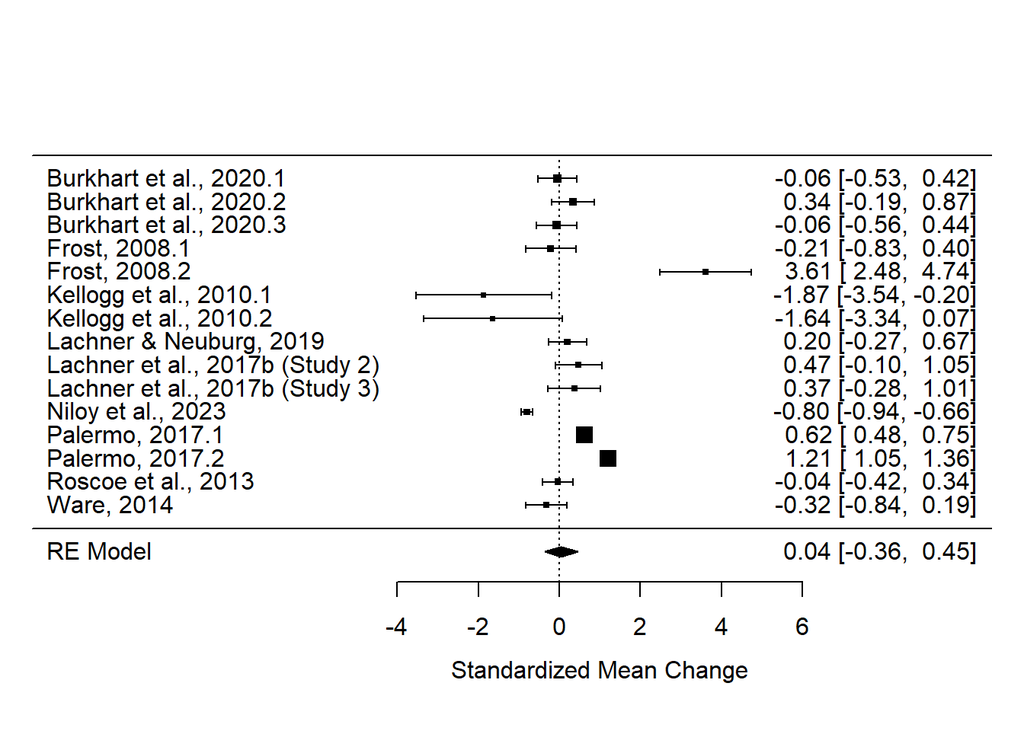

```r
###FOREST PLOT
forest(REM)
```

## Fitting models

Model 1 without cluster vs. Model 2 clustered for author. Better fit for Model 2.

```r
model1 <- rma.mv(  # JS
  yi = yi,
  V = vi,
  data = dat,
  method = "REML")

model2 <- rma.mv(
  yi = yi,
  V = vi,
  data = dat,
  random = ~ 1 | author,
  method = "REML")

anova(model1, model2)
```

```
        df      AIC      BIC     AICc    logLik      LRT   pval       QE
Full     2  89.5528  90.8309  90.6437  -42.7764                 461.6291
Reduced  1 451.8157 452.4547 452.1490 -224.9078 364.2628 <.0001 461.6291
```

```r
#better fit for model 2

# RVE without cluster (dummy coded)
robust(REM, cluster = id, method = "ClubSandwich")
```

[output not shown]

```r
# RVE for author clustered:
robust(REM, cluster = author)
```

```
Multivariate Meta-Analysis Model (k = 15; method: REML)

Variance Components:

           estim   sqrt  nlvls  fixed  factor
sigma^2    0.360  0.600     10     no  author

Test for Heterogeneity:
Q(df = 14) = 461.629, p-val < .001

Number of estimates:   15
Number of clusters:    10
Estimates per cluster: 1-3 (mean: 1.50, median: 1)

Model Results:

estimate     se¹   tval¹  df¹   pval¹   ci.lb¹  ci.ub¹
   0.041  0.206   0.199    9   0.847   -0.426   0.508

---
Signif. codes:  0 '***' 0.001 '**' 0.01 '*' 0.05 '.' 0.1 ' ' 1

1) results based on cluster-robust inference (var-cov estimator: CR1,
   approx t-test and confidence interval, df: residual method)
```

## Bias estimation

### Funnel plot

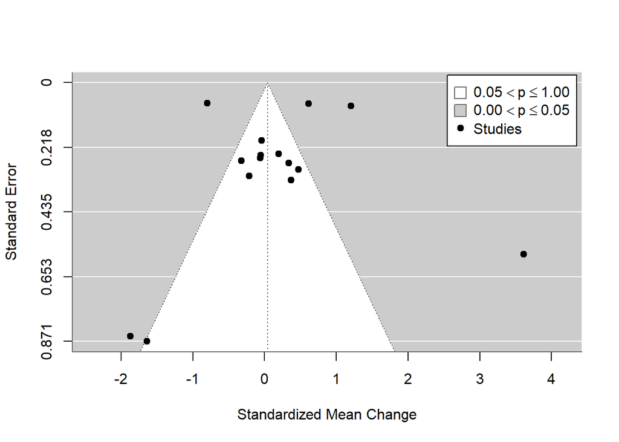

```r
##Funnel plot
funnel(REM, legend = T)
```

### Trim and fill

```r
##Trim & fill
rma_trimfill <- rma(yi, vi, data=dat) # compute random-effects model without
                                      # clustering, as trimfill() can't handle
                                      # these objects
taf_overall <- trimfill(rma_trimfill)
taf_overall
```

```
Estimated number of missing studies on the right side: 5 (SE = 2.5110)

Random-Effects Model (k = 20; tau^2 estimator: REML)

tau^2 (estimated amount of total heterogeneity): 1.3958 (SE = 0.5032)
tau (square root of estimated tau^2 value):      1.1814
I^2 (total heterogeneity / total variability):   98.29%
H^2 (total variability / sampling variability):  58.64

Test for Heterogeneity:
Q(df = 19) = 987.9550, p-val < .0001

Model Results:

estimate      se    zval    pval   ci.lb   ci.ub
  0.6075  0.2797  2.1722  0.0298  0.0593  1.1556  *

---
Signif. codes:  0 '***' 0.001 '**' 0.01 '*' 0.05 '.' 0.1 ' ' 1
```

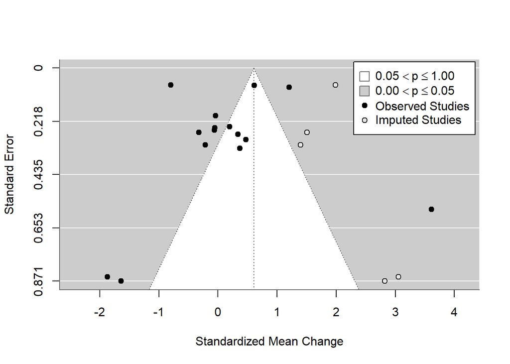

```r
funnel(taf_overall, legend = T)
```

### Egger’s test

```r
##Egger's test
regtest(rma_trimfill)
```

```
Regression Test for Funnel Plot Asymmetry

Model:     mixed-effects meta-regression model
Predictor: standard error

Test for Funnel Plot Asymmetry: z = -0.7481, p = 0.4544
Limit Estimate (as sei -> 0):   b =  0.4609 (CI: -0.4638, 1.3856)
```

## Moderators

For reasons of clarity, we will report results from the moderation analyses based on the meta-analysis with the mean correlations of r_exp = .625 for pre-post and r_control = .765 as the ES does not vary due to different pre-post-correlation.

### Create functions for moderation analyses

```r
r_exp <- .625
r_con <- .765

fn_meta_experimental <- function(moderator, cor_exp, cor_con, data_c) {

data_c <- data_c %>%
  mutate(r_exp = cor_exp,
         r_con = cor_con)

dat_es_exp <- escalc(measure = "SMCR",
                     m1i = M_Feedback2,
                     m2i = M_Feedback,
                     sd1i = SD_Feedback2,
                     sd2i = SD_Feedback,
                     ni= N_Feedback,
                     ri=r_exp,
                     slab = author,
                     data = data_c)

dat_es_con <- escalc(measure = "SMCR",
                     m1i = M_NoFeedback2,
                     m2i = M_NoFeedback,
                     sd1i = SD_NoFeedback2,
                     sd2i = SD_NoFeedback,
                     ni = N_noFeedback,
                     ri= r_con,
                     slab = author,
                     data = data_c)

dat <- data_c %>%
  mutate(yi = dat_es_exp$yi - dat_es_con$yi,
         vi = dat_es_exp$vi + dat_es_con$vi)

# V <- vcalc(vi = vi, cluster = author, subgroup = group, data = dat)

REM <- rma.mv(
    yi = yi,
    V = vi,
    data = dat,
    mods = as.formula(paste("~ factor(", moderator, ") - 1")),
    random = ~ 1 | author,
    method = "REML",
    digits = 2,
    test = "t",
    dfs = "contain"
  )

return(summary(REM))
}

#Q-test

fn_meta_qtest<- function(moderator, cor_exp, cor_con, data_c){
  REM <- fn_meta_experimental(moderator, cor_exp, cor_con, data_c)
  q_extract <- data.frame(
    qe_value = format(round(REM$QE, 2), nsmall = 2),
    qe_df = REM$QEdf,
    qe_p = format(round(REM$QEp, 3), nsmall = 3),
    f_value = format(round(REM$QM, 2), nsmall = 2),
    f_df1 = REM$QMdf[1],
    f_df2 = REM$QMdf[2],
    f_p = format(round(REM$QMp, 3), nsmall = 3))

  q_results <- q_extract %>%
    mutate(moderator = moderator) %>%
    mutate(qe_p = ifelse(qe_p < 0.001, "< .001", as.character(qe_p))) %>%
    mutate(qe_p = gsub("^0\\.", ".", qe_p)) %>%
    mutate(f_p = ifelse(f_p < 0.001, "< .001", as.character(f_p))) %>%
    mutate(f_p = gsub("^0\\.", ".", f_p)) %>%
    mutate(qm_statistics = paste0("QE = ", qe_value,
                                  ", df = ", qe_df,
                                  ", p = ", qe_p,
                                  "\nF(", f_df1,
                                  ", ", f_df2,
                                  ") = ", f_value,
                                  ", p = ", f_p),
           .keep = "unused")}
```

### Moderation analyses

```r
#included moderators
moderators <- c("rep_numeric", "rep_graphical", "rep_highlighting",
                "rep_text_based", "rep_nr", "FB_order", "FB_specificity",
                "order_outcome", "reliability_measurement", "treatment_fidelity",
                "writing_tests", "rank_mean_wq", "post_measure", "experiment",
                "validated_tool", "ceiling_or_flooring_effect", "pretest_equivalence",
                "FB_tool_numbers", "manuscript_type", "education_dummy",
                "setting", "country", "genre", "amount",
                "coding", "system_type", "teacher_effects"
)

# Run moderator analysis
results_moderation <- data.frame()

for (mod in moderators) {
  result <- fn_meta_experimental(moderator = mod, cor_exp = r_exp,
                                 cor_con = r_con, data_c = data_c) %>%
    tidy()
  result$moderator <- mod
  results_moderation <- bind_rows(results_moderation, result)
}

# Test results ------------------------------------------------------------

qtest_results_moderation <- data.frame()

# Loop through each moderator
for (mod in moderators) {
  qtest <- fn_meta_qtest(moderator = mod, cor_exp = r_exp, cor_con = r_con, data = data_c)
  qtest_results_moderation <- rbind(qtest_results_moderation, data.frame(moderator = mod, q_test = qtest))}

# Customize dataset -------------------------------------------------------

number_of_effects <- data_c %>%
  select(any_of(moderators)) %>%
  pivot_longer(everything(), names_to = "moderator", values_to = "term") %>%
  count(moderator, term, name = "k")

descriptive_data <- data_c %>%
  select(N_Feedback, N_noFeedback, any_of(moderators)) %>%
  pivot_longer(-c(N_Feedback, N_noFeedback), names_to = "moderator", values_to = "term") %>%
  group_by(moderator, term) %>%
  summarize(n_exp = sum(N_Feedback),
            n_con = sum(N_noFeedback)) %>%
  mutate(n_exp_con = paste0(n_exp, "/", n_con), .keep = "unused") %>%
  left_join(., number_of_effects, by = c("moderator", "term"))

experimental_final <- results_moderation %>%
  mutate(term = str_remove(term, "^[^)]*\\)")) %>%
  mutate(sig = case_when(
    p.value < .001 ~ "***",
    p.value < .01 ~ "**",
    p.value < .05 ~ "*",
    TRUE ~ "ns"
  )) %>%
  mutate(across(where(is.numeric), ~ round(.x, 3))) %>%
  mutate(across(where(is.numeric), ~ format(.x, nsmall = 3)))%>%
  mutate(p.value = ifelse(p.value < .001, "< .001", as.character(p.value))) %>%
  mutate(p.value = gsub("^0\\.", ".", p.value),
         term = as.numeric(term)) %>%
  left_join(., descriptive_data, by = c("moderator", "term")) %>%
  select(moderator, term, sig, k, n_exp_con, estimate, std.error, statistic, p.value) %>%
  mutate(moderator = if_else(duplicated(moderator), NA_character_, moderator)) %>%
  left_join(., qtest_results_moderation, by = "moderator") %>%
  select(-q_test.moderator)

export(experimental_final, "results_exp.xlsx")


# Post-hoc tests -------------------------------------------------

generate_contrast_matrix <- function(p) {
  if (p < 2) stop("p must be at least 2.")

  # Initialize an empty list to store rows
  contrast_list <- list()

  # Loop through all pairs of coefficients (i, j)
  for (i in 1:(p-1)) {
    for (j in (i+1):p) {
      contrast <- rep(0, p)  # Initialize a row of zeros
      contrast[i] <- -1      # Contrast for the i-th coefficient
      contrast[j] <- 1       # Contrast for the j-th coefficient
      contrast_list <- append(contrast_list, list(contrast))
    }
  }

  contrast_matrix <- do.call(rbind, contrast_list)
  return(contrast_matrix)
}


results_posthoc <- data.frame()

for (mod in moderators) {
  result <- fn_meta_experimental(moderator = mod, cor_exp = r_exp, cor_con = r_con, data_c = data_c)
  result_posthoc <- result %>% tidy()
  result_posthoc$moderator <- mod
  contrast_matrix <- generate_contrast_matrix(result$p)
  anova_result <- data.frame(anova(result, X = contrast_matrix))
  results_posthoc <- bind_rows(results_posthoc, anova_result)
}

results_posthoc <- results_posthoc %>%
  mutate(
    moderator = str_extract(hyp, "(?<=\\().+?(?=\\))"),
    factor_1 = str_extract(hyp, "(?<=\\))[^+]+(?=\\+)") %>% str_trim(),
    factor_2 = str_extract(hyp, "(?<=\\+)\\s*factor\\(.+?\\)([a-zA-Z]+)") %>% str_replace("^.*\\)", "") %>% str_trim(), .keep = "unused"
  ) %>%
  mutate(sig = case_when(
    pval < 0.001 ~ "***",
    pval < 0.01 ~ "**",
    pval < 0.05 ~ "*",
    TRUE ~ "ns"
  )) %>%
  select(moderator, factor_1, factor_2, sig, everything()) %>%
  mutate(across(where(is.numeric), ~ round(.x, 3))) %>%
  mutate(across(where(is.numeric), ~ format(.x, nsmall = 3)))%>%
  mutate(pval = ifelse(pval < 0.001, "< .001", as.character(pval))) %>%
  mutate(pval = gsub("^0\\.", ".", pval))
```

# Computational Environment